[figure not shown]

# Project Jupyter for geosciences

### Ian Rose (UC Berkeley)

### CIG Webinar

### February 9, 2017

### Talk overview

- What is Jupyter?
- Usage of the notebook
- Applications in geoscience
- Advanced usage

### What is Jupyter?

Project Jupyter is a collection of tools for interactive and exploratory data analysis, including tools for sharing that analysis.

### Project Jupyter

is the language-agnostic parts of IPython, rebranded. There are now kernels for over 70 programming languages implemented, all of which may use the same frontends.

### This is limited...

[figure not shown]

### Co-opting the web browser

- Images
- Rich text
- Equations
- Sound
- Video
- UI elements

### Architecture

[figure not shown]

### Usage of the notebook

- Code cells
- Markdown Cells
- HTML rendering

```python
# This is a code cell
print("Hello world")
```

```
Hello world
```

### This is a markdown cell

Swanson-Hysell et al., 2014

[figure not shown]

### Cartopy

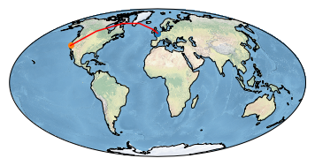

```python
ax = plt.axes(projection=ccrs.Mollweide())
ax.set_global()
ax.stock_img()
ax.coastlines()

London = [-0.08, 51.53]
SF = [-122.42, 37.77]
Joburg = [28.05, -26.20]

plt.plot(*London, 'o', transform=ccrs.PlateCarree())
plt.plot(*SF, 'o', transform=ccrs.PlateCarree())
plt.plot([SF[0], London[0]], [SF[1],London[1]], \
         c='r', transform=ccrs.Geodetic())

plt.show()
```

### Leaflet.js

```python
import json
import ipyleaflet as ll
map = ll.Map(center=[53.88,27.45], zoom=4)
data = json.load(open('./europe_110.geo.json'))
for feature in data['features']:
    feature['properties']['style'] = {'color': 'grey','weight': 1,'fillColor': 'grey','fillOpacity': 0.5}
layer = ll.GeoJSON(data=data, hover_style={'fillColor': 'red'})
map.add_layer(layer)
map
```

[output not shown]

### Advanced usage

- Widgets
- Serving notebooks over the internet
- JupyterHub

### Demo

test.burnman.org

(thanks to Timo Heister)

### Demo

seismo-live.org

(thanks to Heiner Igel et al.)

### Jupyterhub

[figure not shown]